# Analisis univariable: analisis descriptivo y temporal y preprocesado

# 3. Analisis univariable-distribucion de la produccion

```r
#Distribucion tipo producci??n
produccion<-data.frame(electricity_prices$eol, electricity_prices$nuc, electricity_prices$tot, electricity_prices$hid, electricity_prices$cco, electricity_prices$sol)
names(produccion)<-c("eolica", "nuclear", "total", "hidraulica", "cco", "solar")
summary(produccion)
```

```
     eolica         nuclear         total         hidraulica         cco            solar
 Min.   :  178   Min.   :   0   Min.   : 7117   Min.   :10334   Min.   :14176   Min.   :    0.0
 1st Qu.: 3024   1st Qu.:6106   1st Qu.:52425   1st Qu.:12658   1st Qu.:21983   1st Qu.:   85.5
 Median : 4875   Median :7117   Median :54310   Median :13345   Median :22987   Median :  599.7
 Mean   : 5517   Mean   :6481   Mean   :54187   Mean   :13269   Mean   :22664   Mean   : 1482.3
 3rd Qu.: 7462   3rd Qu.:7117   3rd Qu.:55998   3rd Qu.:14005   3rd Qu.:23433   3rd Qu.: 2714.8
 Max.   :17430   Max.   :7117   Max.   :60855   Max.   :56684   Max.   :24560   Max.   :22604.1
                                                NA's   :24                      NA's   :1
```

```r
#Observamos los valores NA de produccion hidraulica (registros con missing data)
hid.na<-electricity_prices[is.na(electricity_prices$hid),]
hid.na
```

|  | Date | Hour | DayofWeek | Month | WeekofMonth | MD | MI1 | MI2 | MI3 | MI4 | MI5 | MI6 | MI7 | dem | eol | nuc | tot | hid | cco | sol | demres | PM |
| --- | --- | --- | --- | --- | --- | --- | --- | --- | --- | --- | --- | --- | --- | --- | --- | --- | --- | --- | --- | --- | --- | --- |
| 31632 | 2017-08-11 | 1 | 5 | 8 | 2 | 37.86 | 36.00 | 36.86 | NA | NA | NA | NA | NA | 28201 | 8283 | 7024.3 | 53864.9 | NA | 23739.5 | 570.4 | 18399.6 | 36.91 |
| 31633 | 2017-08-11 | 2 | 5 | 8 | 2 | 35.00 | 33.01 | 32.10 | NA | NA | NA | NA | NA | 26604 | 7894 | 7024.3 | 53864.9 | NA | 23739.5 | 530.6 | 17078.4 | 33.37 |
| 31634 | 2017-08-11 | 3 | 5 | 8 | 2 | 32.89 | 30.55 | 27.11 | NA | NA | NA | NA | NA | 25251 | 7541 | 7117.2 | 53957.8 | NA | 23739.5 | 459.1 | 16304.9 | 30.18 |
| 31635 | 2017-08-11 | 4 | 5 | 8 | 2 | 32.50 | 30.00 | 28.00 | NA | NA | NA | NA | NA | 24551 | 7181 | 7117.2 | 53957.8 | NA | 23739.5 | 417.5 | 16108.5 | 30.17 |
| 31636 | 2017-08-11 | 5 | 5 | 8 | 2 | 32.60 | 31.10 | 31.60 | 28.60 | NA | NA | NA | NA | 24430 | 6788 | 7117.2 | 53957.8 | NA | 23739.5 | 363.3 | 16319.7 | 30.98 |
| 31637 | 2017-08-11 | 6 | 5 | 8 | 2 | 33.19 | 31.69 | 33.17 | 30.00 | NA | NA | NA | NA | 24462 | 6565 | 7117.2 | 53957.8 | NA | 23739.5 | 295.3 | 16818.7 | 32.01 |
| 31638 | 2017-08-11 | 7 | 5 | 8 | 2 | 37.86 | 35.88 | 36.86 | 37.09 | NA | NA | NA | NA | 25782 | 6384 | 7117.2 | 53957.8 | NA | 23739.5 | 216.7 | 18433.3 | 36.92 |
| 31639 | 2017-08-11 | 8 | 5 | 8 | 2 | 39.57 | 37.57 | 38.57 | 41.14 | 40.98 | NA | NA | NA | 26987 | 6190 | 7117.2 | 53957.8 | NA | 23739.5 | 242.1 | 19976.9 | 39.57 |
| 31640 | 2017-08-11 | 9 | 5 | 8 | 2 | 43.26 | 42.26 | 42.76 | 41.39 | 43.00 | NA | NA | NA | 28582 | 5854 | 7117.2 | 53957.8 | NA | 23739.5 | 884.7 | 21467.3 | 42.53 |
| 31641 | 2017-08-11 | 10 | 5 | 8 | 2 | 45.20 | 43.70 | 44.20 | 43.39 | 45.20 | NA | NA | NA | 30405 | 5465 | 7117.2 | 53957.8 | NA | 23739.5 | 2125.6 | 22477.4 | 44.34 |

[output cut: 14 more lines]

Probablemente debido a algun error informatico no tenemos informacion de produccion hidraulica el 11/08. Por lo tanto, se deberan descartar estas filas cuando se analice la produccion

```r
#Observamos los valores NA (registros con missing data) de produccion solar
sol.na<-electricity_prices[is.na(electricity_prices$sol),]
sol.na
```

|  | Date | Hour | DayofWeek | Month | WeekofMonth | MD | MI1 | MI2 | MI3 | MI4 | MI5 | MI6 | MI7 | dem | eol | nuc | tot | hid | cco | sol | demres | PM |
| --- | --- | --- | --- | --- | --- | --- | --- | --- | --- | --- | --- | --- | --- | --- | --- | --- | --- | --- | --- | --- | --- | --- |
| 28322 | 2017-03-26 | 3 | 7 | 3 | 4 | 33.75 | 35.56 | 35.65 | NA | NA | NA | NA | NA | 21302 | 5416 | 7117.2 | 54135 | 14186.2 | 21509.6 | NA | NA | 34.99 |

Probablemente debido a un error informatico no tenemos informacion de produccion solar el 26/03. Por lo tanto, se debera descartar esta filas cuando se analice la produccion

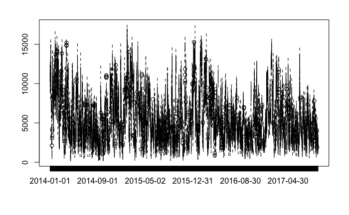

```r
plot(electricity_prices$Date, electricity_prices$eol)
```

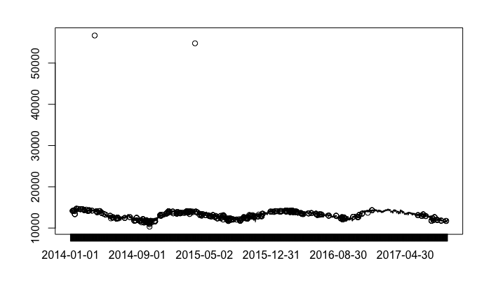

```r
plot(electricity_prices$Date, electricity_prices$hid)
```

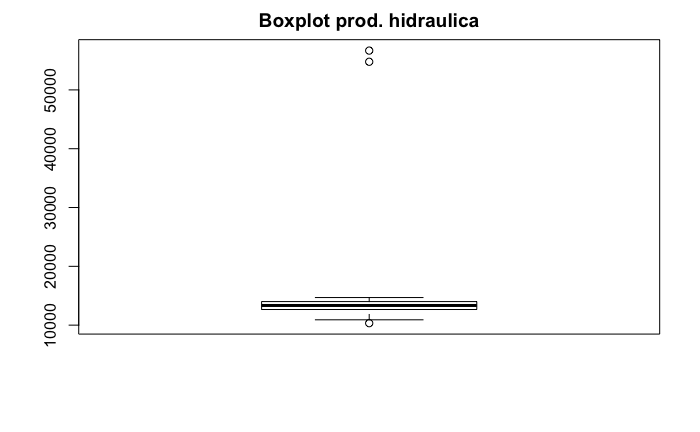

```r
boxplot(electricity_prices$hid, main="Boxplot prod. hidraulica")
```

# Observamos que existen un par de outliers que estan distorsionando la distribucion. Comprobamos el efecto de eliminar estas observaciones:

```r
outliers<-boxplot.stats(electricity_prices$hid)$out
outliers
```

```
[1] 56684.3 10333.5 54785.1
```

```r
#Observamos los datos de los outliers encontrados en la produccion hidraulica
electricity_prices[electricity_prices$hid>54785,]
```

|  | Date | Hour | DayofWeek | Month | WeekofMonth | MD | MI1 | MI2 | MI3 | MI4 | MI5 | MI6 | MI7 | dem | eol | nuc | tot | hid | cco | sol | demres | PM |
| --- | --- | --- | --- | --- | --- | --- | --- | --- | --- | --- | --- | --- | --- | --- | --- | --- | --- | --- | --- | --- | --- | --- |
| 2115 | 2014-03-30 | 3 | 7 | 3 | 5 | 26.00 | 33.1 | 30.0 | NA | NA | NA | NA | NA | 21400 | 6352 | 0 | 7117.2 | 56684.3 | 14348.2 | 22229.3 | 0.2 | 29.70 |
| 10851 | 2015-03-29 | 3 | 7 | 3 | 5 | 28.75 | 27.8 | 22.2 | NA | NA | NA | NA | NA | 20908 | 6775 | 0 | 7117.2 | 54785.1 | 14175.6 | 22604.1 | 148.4 | 26.25 |
| NA | NA | NA | NA | NA | NA | NA | NA | NA | NA | NA | NA | NA | NA | NA | NA | NA | NA | NA | NA | NA | NA | NA |
| NA.1 | NA | NA | NA | NA | NA | NA | NA | NA | NA | NA | NA | NA | NA | NA | NA | NA | NA | NA | NA | NA | NA | NA |
| NA.2 | NA | NA | NA | NA | NA | NA | NA | NA | NA | NA | NA | NA | NA | NA | NA | NA | NA | NA | NA | NA | NA | NA |
| NA.3 | NA | NA | NA | NA | NA | NA | NA | NA | NA | NA | NA | NA | NA | NA | NA | NA | NA | NA | NA | NA | NA | NA |
| NA.4 | NA | NA | NA | NA | NA | NA | NA | NA | NA | NA | NA | NA | NA | NA | NA | NA | NA | NA | NA | NA | NA | NA |
| NA.5 | NA | NA | NA | NA | NA | NA | NA | NA | NA | NA | NA | NA | NA | NA | NA | NA | NA | NA | NA | NA | NA | NA |
| NA.6 | NA | NA | NA | NA | NA | NA | NA | NA | NA | NA | NA | NA | NA | NA | NA | NA | NA | NA | NA | NA | NA | NA |
| NA.7 | NA | NA | NA | NA | NA | NA | NA | NA | NA | NA | NA | NA | NA | NA | NA | NA | NA | NA | NA | NA | NA | NA |

[output cut: 16 more lines]

```r
#Creamos objeto con outliers produccion hidraulica
out_hid<-c(56684.3, 54785.1)
out_hid
```

```
[1] 56684.3 54785.1
```

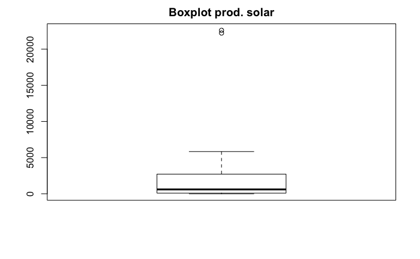

```r
#Distribucion produccion solar
boxplot(electricity_prices$sol, main="Boxplot prod. solar")
```

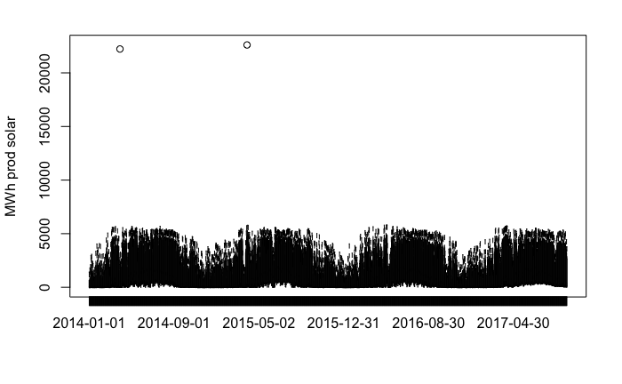

```r
#Realizamos grafico con la evolucion temporal de la produccion solar
plot(electricity_prices$Date, electricity_prices$sol, ylab= "MWh prod solar")
```

Se distinguen claramente los outliers en la parte superior del grafico

```r
#Creamos objeto con outliers
outliers2<-boxplot.stats(electricity_prices$sol)$out
outliers2
```

```
[1] 22229.3 22604.1
```

```r
#Observamos los datos de los outliers encontrados en produccion solar
electricity_prices[electricity_prices$sol>22229,]
```

|  | Date | Hour | DayofWeek | Month | WeekofMonth | MD | MI1 | MI2 | MI3 | MI4 | MI5 | MI6 | MI7 | dem | eol | nuc | tot | hid | cco | sol | demres | PM |
| --- | --- | --- | --- | --- | --- | --- | --- | --- | --- | --- | --- | --- | --- | --- | --- | --- | --- | --- | --- | --- | --- | --- |
| 2115 | 2014-03-30 | 3 | 7 | 3 | 5 | 26.00 | 33.1 | 30.0 | NA | NA | NA | NA | NA | 21400 | 6352 | 0 | 7117.2 | 56684.3 | 14348.2 | 22229.3 | 0.2 | 29.70 |
| 10851 | 2015-03-29 | 3 | 7 | 3 | 5 | 28.75 | 27.8 | 22.2 | NA | NA | NA | NA | NA | 20908 | 6775 | 0 | 7117.2 | 54785.1 | 14175.6 | 22604.1 | 148.4 | 26.25 |
| NA | NA | NA | NA | NA | NA | NA | NA | NA | NA | NA | NA | NA | NA | NA | NA | NA | NA | NA | NA | NA | NA | NA |

Comprobamos que se trata de los mismos outliers detectados para la produccion hidraulica. Ambos coinciden en observaciones realizadas a finales de marzo, tanto el a??o 2014 como el 2015 a las 3 de la madrugada

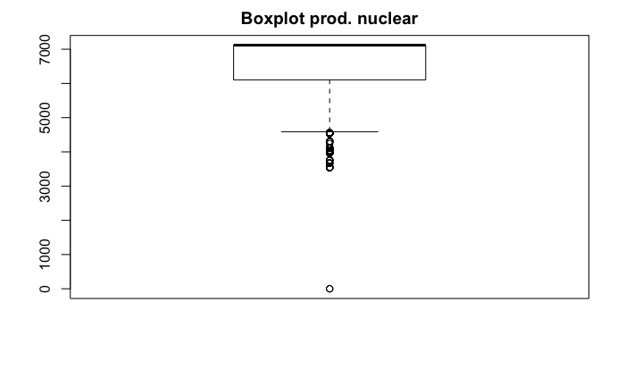

```r
boxplot(electricity_prices$nuc, main="Boxplot prod. nuclear")
```

```r
#Creamos objeto con outliers produccion nuclear
outliers3<-boxplot.stats(electricity_prices$nuc)$out
head(outliers3)
```

```
[1]    0.0 4557.2 4557.2 4557.2 4557.2 4557.2
```

```r
#Observamos los datos de los outliers encontrados
electricity_prices[electricity_prices$nuc<1000,]
```

|  | Date | Hour | DayofWeek | Month | WeekofMonth | MD | MI1 | MI2 | MI3 | MI4 | MI5 | MI6 | MI7 | dem | eol | nuc | tot | hid | cco | sol | demres | PM |
| --- | --- | --- | --- | --- | --- | --- | --- | --- | --- | --- | --- | --- | --- | --- | --- | --- | --- | --- | --- | --- | --- | --- |
| 2115 | 2014-03-30 | 3 | 7 | 3 | 5 | 26.00 | 33.1 | 30.0 | NA | NA | NA | NA | NA | 21400 | 6352 | 0 | 7117.2 | 56684.3 | 14348.2 | 22229.3 | 0.2 | 29.70 |
| 10851 | 2015-03-29 | 3 | 7 | 3 | 5 | 28.75 | 27.8 | 22.2 | NA | NA | NA | NA | NA | 20908 | 6775 | 0 | 7117.2 | 54785.1 | 14175.6 | 22604.1 | 148.4 | 26.25 |

De nuevo, los outliers que distorsionan con mas intensidad la distribucion coinciden con los detectados anteriormente

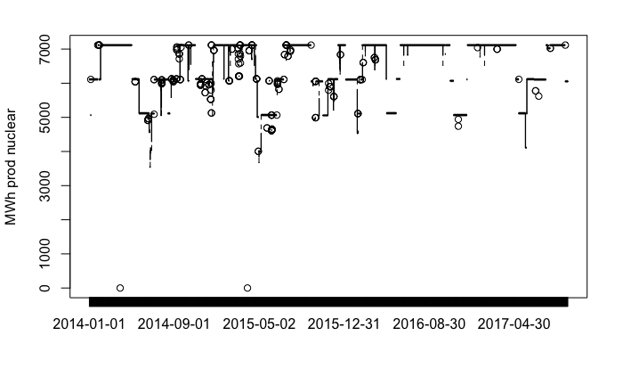

```r
#Distribucion produccion nuclear
plot(electricity_prices$Date, electricity_prices$nuc, ylab="MWh prod nuclear")
```

Se distinguen claramente los outliers en la parte inferior del grafico

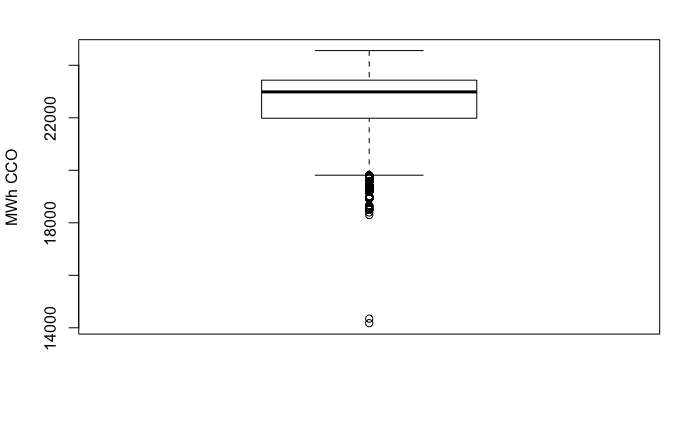

```r
#Distribucion produccion ciclo combinado
boxplot(electricity_prices$cco, ylab = "MWh CCO")
```

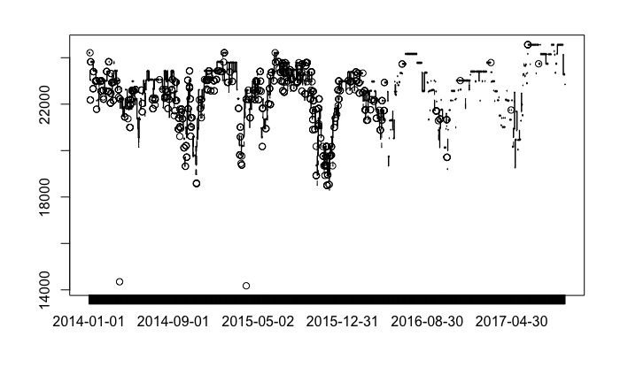

```r
#Grafico evolucion produccion CCO temporal
plot(electricity_prices$Date, electricity_prices$cco)
```

```r
#Creamos objeto con outliers produccion cco
outliers4<-boxplot.stats(electricity_prices$cco)$out
head(outliers4)
```

```
[1] 14348.2 19702.1 19702.1 19702.1 19702.1 19702.1
```

```r
#Observamos los datos de los outliers encontrados
electricity_prices[electricity_prices$cco<15000,]
```

|  | Date | Hour | DayofWeek | Month | WeekofMonth | MD | MI1 | MI2 | MI3 | MI4 | MI5 | MI6 | MI7 | dem | eol | nuc | tot | hid | cco | sol | demres | PM |
| --- | --- | --- | --- | --- | --- | --- | --- | --- | --- | --- | --- | --- | --- | --- | --- | --- | --- | --- | --- | --- | --- | --- |
| 2115 | 2014-03-30 | 3 | 7 | 3 | 5 | 26.00 | 33.1 | 30.0 | NA | NA | NA | NA | NA | 21400 | 6352 | 0 | 7117.2 | 56684.3 | 14348.2 | 22229.3 | 0.2 | 29.70 |
| 10851 | 2015-03-29 | 3 | 7 | 3 | 5 | 28.75 | 27.8 | 22.2 | NA | NA | NA | NA | NA | 20908 | 6775 | 0 | 7117.2 | 54785.1 | 14175.6 | 22604.1 | 148.4 | 26.25 |

```r
#Observamos los datos de los outliers encontrados con fecha 2014
electricity_prices[electricity_prices$Date=="2014-03-30",]
```

|  | Date | Hour | DayofWeek | Month | WeekofMonth | MD | MI1 | MI2 | MI3 | MI4 | MI5 | MI6 | MI7 | dem | eol | nuc | tot | hid | cco | sol | demres | PM |
| --- | --- | --- | --- | --- | --- | --- | --- | --- | --- | --- | --- | --- | --- | --- | --- | --- | --- | --- | --- | --- | --- | --- |
| 2113 | 2014-03-30 | 1 | 7 | 3 | 5 | 33.20 | 34.00 | 30.20 | NA | NA | NA | NA | NA | 24678.00 | 6780.00 | 7117.2 | 56684.3 | 14348.2 | 22229.3 | 18.9 | 18736.0 | 32.47 |
| 2114 | 2014-03-30 | 2 | 7 | 3 | 5 | 31.10 | 36.10 | 29.88 | NA | NA | NA | NA | NA | 22845.00 | 6363.00 | 7117.2 | 56684.3 | 14348.2 | 22229.3 | 0.1 | 17261.5 | 32.36 |
| 2115 | 2014-03-30 | 3 | 7 | 3 | 5 | 26.00 | 33.10 | 30.00 | NA | NA | NA | NA | NA | 21400.00 | 6352.00 | 0.0 | 7117.2 | 56684.3 | 14348.2 | 22229.3 | 0.2 | 29.70 |
| 2116 | 2014-03-30 | 4 | 7 | 3 | 5 | 20.90 | 30.14 | 30.14 | NA | NA | NA | NA | NA | 20600.00 | 6129.00 | 7117.2 | 56684.3 | 14348.2 | 22229.3 | 0.4 | 13784.7 | 27.06 |
| 2117 | 2014-03-30 | 5 | 7 | 3 | 5 | 18.44 | 29.14 | 29.84 | 14.50 | NA | NA | NA | NA | 20200.00 | 6133.00 | 7117.2 | 56684.3 | 14348.2 | 22229.3 | 6.3 | 13189.5 | 22.98 |
| 2118 | 2014-03-30 | 6 | 7 | 3 | 5 | 16.20 | 29.01 | 29.88 | 21.20 | NA | NA | NA | NA | 20400.00 | 6238.00 | 7117.2 | 56684.3 | 14348.2 | 22229.3 | 16.1 | 12970.0 | 24.07 |
| 2119 | 2014-03-30 | 7 | 7 | 3 | 5 | 20.10 | 27.14 | 25.50 | 25.10 | NA | NA | NA | NA | 20800.00 | 6070.00 | 7117.2 | 56684.3 | 14348.2 | 22229.3 | 16.1 | 12959.9 | 24.46 |
| 2120 | 2014-03-30 | 8 | 7 | 3 | 5 | 20.90 | 29.14 | 28.88 | 25.90 | 30.60 | NA | NA | NA | 20750.00 | 5751.00 | 7117.2 | 56684.3 | 14348.2 | 22229.3 | 12.0 | 13663.8 | 27.08 |
| 2121 | 2014-03-30 | 9 | 7 | 3 | 5 | 20.90 | 26.46 | 27.14 | 25.90 | 30.60 | NA | NA | NA | 22400.00 | 5562.00 | 7117.2 | 56595.6 | 14348.2 | 22229.3 | 187.1 | 13805.5 | 26.20 |
| 2122 | 2014-03-30 | 10 | 7 | 3 | 5 | 22.90 | 29.14 | 26.40 | 27.90 | 32.05 | NA | NA | NA | 24500.00 | 5442.00 | 7117.2 | 56684.3 | 14348.2 | 22229.3 | 729.2 | 14950.4 | 27.68 |

[output cut: 14 more lines]

Definitivamente existe un error en esta observacion. Los valores estan incorrectamente clasificados (por ejemplo, el valor de produccion con energia hidraulica esta incorrectamente clasificado bajo produccion cco)

```r
#Observamos los datos de los outliers encontrados con fecha 2015
electricity_prices[electricity_prices$Date=="2015-03-29",]
```

|  | Date | Hour | DayofWeek | Month | WeekofMonth | MD | MI1 | MI2 | MI3 | MI4 | MI5 | MI6 | MI7 | dem | eol | nuc | tot | hid | cco | sol | demres | PM |
| --- | --- | --- | --- | --- | --- | --- | --- | --- | --- | --- | --- | --- | --- | --- | --- | --- | --- | --- | --- | --- | --- | --- |
| 10849 | 2015-03-29 | 1 | 7 | 3 | 5 | 34.50 | 29.23 | 24.90 | NA | NA | NA | NA | NA | 24038.00 | 6920.00 | 7117.2 | 54843.8 | 14175.6 | 22604.1 | 401.5 | 16716.5 | 29.54 |
| 10850 | 2015-03-29 | 2 | 7 | 3 | 5 | 32.68 | 31.22 | 24.42 | NA | NA | NA | NA | NA | 22323.00 | 6731.00 | 7117.2 | 54785.1 | 14175.6 | 22604.1 | 152.4 | 15439.6 | 29.44 |
| 10851 | 2015-03-29 | 3 | 7 | 3 | 5 | 28.75 | 27.80 | 22.20 | NA | NA | NA | NA | NA | 20908.00 | 6775.00 | 0.0 | 7117.2 | 54785.1 | 14175.6 | 22604.1 | 148.4 | 26.25 |
| 10852 | 2015-03-29 | 4 | 7 | 3 | 5 | 29.48 | 24.42 | 20.00 | NA | NA | NA | NA | NA | 20312.00 | 7151.00 | 7117.2 | 54843.8 | 14175.6 | 22604.1 | 144.8 | 13988.2 | 24.63 |
| 10853 | 2015-03-29 | 5 | 7 | 3 | 5 | 28.75 | 24.48 | 20.64 | 16.64 | NA | NA | NA | NA | 20212.00 | 7483.00 | 7117.2 | 54843.8 | 14175.6 | 22604.1 | 304.9 | 12856.1 | 22.63 |
| 10854 | 2015-03-29 | 6 | 7 | 3 | 5 | 30.45 | 27.29 | 24.90 | 14.99 | NA | NA | NA | NA | 20698.00 | 7678.00 | 7117.2 | 54843.8 | 14175.6 | 22604.1 | 287.4 | 12441.6 | 24.41 |
| 10855 | 2015-03-29 | 7 | 7 | 3 | 5 | 29.48 | 28.32 | 29.65 | 17.65 | NA | NA | NA | NA | 21330.00 | 7818.00 | 7117.2 | 54843.8 | 14175.6 | 22604.1 | 211.2 | 12808.8 | 26.27 |
| 10856 | 2015-03-29 | 8 | 7 | 3 | 5 | 28.50 | 24.42 | 28.68 | 24.71 | 0.00 | NA | NA | NA | 21212.00 | 7455.00 | 7117.2 | 54843.8 | 14175.6 | 22604.1 | 109.7 | 13402.3 | 21.26 |
| 10857 | 2015-03-29 | 9 | 7 | 3 | 5 | 34.00 | 24.42 | 28.50 | 28.50 | 14.25 | NA | NA | NA | 22800.00 | 6870.00 | 7117.2 | 54843.8 | 14175.6 | 22604.1 | 450.4 | 13306.6 | 25.93 |
| 10858 | 2015-03-29 | 10 | 7 | 3 | 5 | 34.50 | 30.91 | 33.85 | 32.00 | 20.35 | NA | NA | NA | 24500.00 | 6567.00 | 7117.2 | 54843.8 | 14175.6 | 22604.1 | 1459.9 | 14470.1 | 30.32 |

[output cut: 14 more lines]

De nuevo, el valor de las observaciones se encuentra mal clasificado

# 2.3.1 Eliminacion de outliers

```r
#Arreglamos el primer outlier:
electricity_prices[2115,]$hid<- 14175.6
electricity_prices[2115,]$nuc<- 7117.2
electricity_prices[2115,]$tot<- 56684.3
electricity_prices[2115,]$cco<- 22229.3
electricity_prices[2115,]$sol<- 0.2
```

```r
#Observamos los datos del outlier arreglado
electricity_prices[electricity_prices$Date=="2014-03-30",]
```

|  | Date | Hour | DayofWeek | Month | WeekofMonth | MD | MI1 | MI2 | MI3 | MI4 | MI5 | MI6 | MI7 | dem | eol | nuc | tot | hid | cco | sol | demres | PM |
| --- | --- | --- | --- | --- | --- | --- | --- | --- | --- | --- | --- | --- | --- | --- | --- | --- | --- | --- | --- | --- | --- | --- |
| 2113 | 2014-03-30 | 1 | 7 | 3 | 5 | 33.20 | 34.00 | 30.20 | NA | NA | NA | NA | NA | 24678.00 | 6780.00 | 7117.2 | 56684.3 | 14348.2 | 22229.3 | 18.9 | 18736.0 | 32.47 |
| 2114 | 2014-03-30 | 2 | 7 | 3 | 5 | 31.10 | 36.10 | 29.88 | NA | NA | NA | NA | NA | 22845.00 | 6363.00 | 7117.2 | 56684.3 | 14348.2 | 22229.3 | 0.1 | 17261.5 | 32.36 |
| 2115 | 2014-03-30 | 3 | 7 | 3 | 5 | 26.00 | 33.10 | 30.00 | NA | NA | NA | NA | NA | 21400.00 | 6352.00 | 7117.2 | 56684.3 | 14175.6 | 22229.3 | 0.2 | 0.2 | 29.70 |
| 2116 | 2014-03-30 | 4 | 7 | 3 | 5 | 20.90 | 30.14 | 30.14 | NA | NA | NA | NA | NA | 20600.00 | 6129.00 | 7117.2 | 56684.3 | 14348.2 | 22229.3 | 0.4 | 13784.7 | 27.06 |
| 2117 | 2014-03-30 | 5 | 7 | 3 | 5 | 18.44 | 29.14 | 29.84 | 14.50 | NA | NA | NA | NA | 20200.00 | 6133.00 | 7117.2 | 56684.3 | 14348.2 | 22229.3 | 6.3 | 13189.5 | 22.98 |
| 2118 | 2014-03-30 | 6 | 7 | 3 | 5 | 16.20 | 29.01 | 29.88 | 21.20 | NA | NA | NA | NA | 20400.00 | 6238.00 | 7117.2 | 56684.3 | 14348.2 | 22229.3 | 16.1 | 12970.0 | 24.07 |
| 2119 | 2014-03-30 | 7 | 7 | 3 | 5 | 20.10 | 27.14 | 25.50 | 25.10 | NA | NA | NA | NA | 20800.00 | 6070.00 | 7117.2 | 56684.3 | 14348.2 | 22229.3 | 16.1 | 12959.9 | 24.46 |
| 2120 | 2014-03-30 | 8 | 7 | 3 | 5 | 20.90 | 29.14 | 28.88 | 25.90 | 30.60 | NA | NA | NA | 20750.00 | 5751.00 | 7117.2 | 56684.3 | 14348.2 | 22229.3 | 12.0 | 13663.8 | 27.08 |
| 2121 | 2014-03-30 | 9 | 7 | 3 | 5 | 20.90 | 26.46 | 27.14 | 25.90 | 30.60 | NA | NA | NA | 22400.00 | 5562.00 | 7117.2 | 56595.6 | 14348.2 | 22229.3 | 187.1 | 13805.5 | 26.20 |
| 2122 | 2014-03-30 | 10 | 7 | 3 | 5 | 22.90 | 29.14 | 26.40 | 27.90 | 32.05 | NA | NA | NA | 24500.00 | 5442.00 | 7117.2 | 56684.3 | 14348.2 | 22229.3 | 729.2 | 14950.4 | 27.68 |

[output cut: 14 more lines]

```r
#Arreglamos el segundo outlier:
electricity_prices$hid<- ifelse(electricity_prices$hid==54785.1,14175.6,electricity_prices$hid)
electricity_prices$nuc<- ifelse(electricity_prices$nuc==0.0,7117.2,electricity_prices$nuc)
electricity_prices$tot<- ifelse(electricity_prices$tot==7117.2,54785.1,electricity_prices$tot)
electricity_prices$cco<- ifelse(electricity_prices$cco==14175.6,22604.1,electricity_prices$cco)
electricity_prices$sol<- ifelse(electricity_prices$sol==22604.1,148.4,electricity_prices$sol)
```

```r
#Observamos los datos del outlier arreglado
electricity_prices[electricity_prices$Date=="2015-03-29",]
```

|  | Date | Hour | DayofWeek | Month | WeekofMonth | MD | MI1 | MI2 | MI3 | MI4 | MI5 | MI6 | MI7 | dem | eol | nuc | tot | hid | cco | sol | demres | PM |
| --- | --- | --- | --- | --- | --- | --- | --- | --- | --- | --- | --- | --- | --- | --- | --- | --- | --- | --- | --- | --- | --- | --- |
| 10849 | 2015-03-29 | 1 | 7 | 3 | 5 | 34.50 | 29.23 | 24.90 | NA | NA | NA | NA | NA | 24038.00 | 6920.00 | 7117.2 | 54843.8 | 14175.6 | 22604.1 | 401.5 | 16716.5 | 29.54 |
| 10850 | 2015-03-29 | 2 | 7 | 3 | 5 | 32.68 | 31.22 | 24.42 | NA | NA | NA | NA | NA | 22323.00 | 6731.00 | 7117.2 | 54785.1 | 14175.6 | 22604.1 | 152.4 | 15439.6 | 29.44 |
| 10851 | 2015-03-29 | 3 | 7 | 3 | 5 | 28.75 | 27.80 | 22.20 | NA | NA | NA | NA | NA | 20908.00 | 6775.00 | 7117.2 | 54785.1 | 14175.6 | 22604.1 | 148.4 | 148.4 | 26.25 |
| 10852 | 2015-03-29 | 4 | 7 | 3 | 5 | 29.48 | 24.42 | 20.00 | NA | NA | NA | NA | NA | 20312.00 | 7151.00 | 7117.2 | 54843.8 | 14175.6 | 22604.1 | 144.8 | 13988.2 | 24.63 |
| 10853 | 2015-03-29 | 5 | 7 | 3 | 5 | 28.75 | 24.48 | 20.64 | 16.64 | NA | NA | NA | NA | 20212.00 | 7483.00 | 7117.2 | 54843.8 | 14175.6 | 22604.1 | 304.9 | 12856.1 | 22.63 |
| 10854 | 2015-03-29 | 6 | 7 | 3 | 5 | 30.45 | 27.29 | 24.90 | 14.99 | NA | NA | NA | NA | 20698.00 | 7678.00 | 7117.2 | 54843.8 | 14175.6 | 22604.1 | 287.4 | 12441.6 | 24.41 |
| 10855 | 2015-03-29 | 7 | 7 | 3 | 5 | 29.48 | 28.32 | 29.65 | 17.65 | NA | NA | NA | NA | 21330.00 | 7818.00 | 7117.2 | 54843.8 | 14175.6 | 22604.1 | 211.2 | 12808.8 | 26.27 |
| 10856 | 2015-03-29 | 8 | 7 | 3 | 5 | 28.50 | 24.42 | 28.68 | 24.71 | 0.00 | NA | NA | NA | 21212.00 | 7455.00 | 7117.2 | 54843.8 | 14175.6 | 22604.1 | 109.7 | 13402.3 | 21.26 |
| 10857 | 2015-03-29 | 9 | 7 | 3 | 5 | 34.00 | 24.42 | 28.50 | 28.50 | 14.25 | NA | NA | NA | 22800.00 | 6870.00 | 7117.2 | 54843.8 | 14175.6 | 22604.1 | 450.4 | 13306.6 | 25.93 |
| 10858 | 2015-03-29 | 10 | 7 | 3 | 5 | 34.50 | 30.91 | 33.85 | 32.00 | 20.35 | NA | NA | NA | 24500.00 | 6567.00 | 7117.2 | 54843.8 | 14175.6 | 22604.1 | 1459.9 | 14470.1 | 30.32 |

[output cut: 14 more lines]

# Volvemos a realizar el analisis temporal y descrptivo

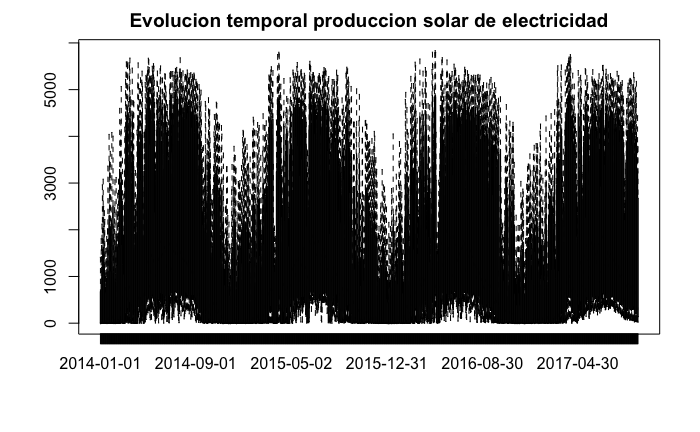

```r
#Produccion solar
plot(electricity_prices$Date, electricity_prices$sol, main= "Evolucion temporal produccion solar de electricidad")
```

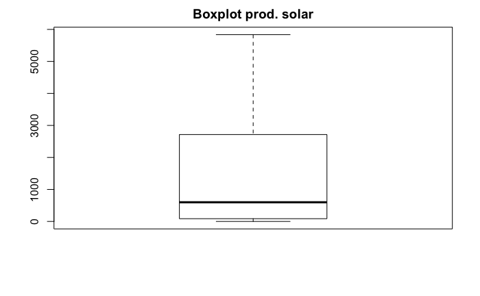

```r
#Distribucion produccion solar
boxplot(electricity_prices$sol, main="Boxplot prod. solar")
```

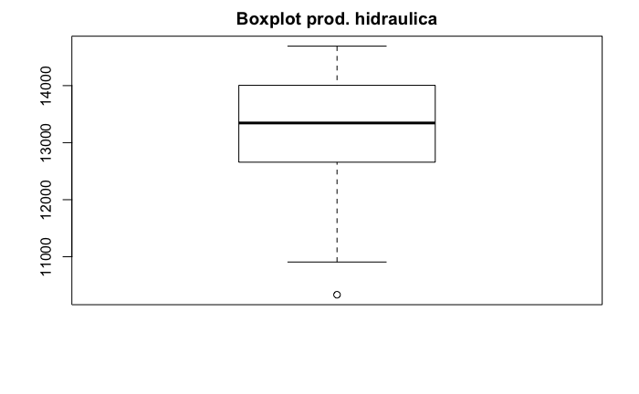

```r
#Distribucion produccion hidraulica de electricidad
boxplot(electricity_prices$hid, main="Boxplot prod. hidraulica")
```

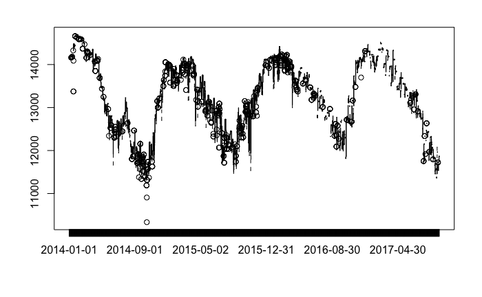

```r
#Evolucion temporal produccion hidraulica
plot(electricity_prices$Date, electricity_prices$hid)
```

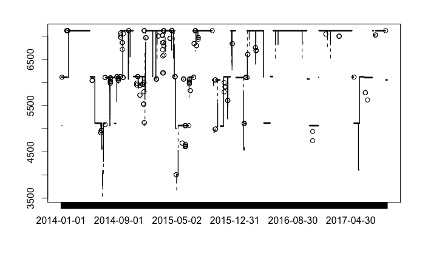

```r
#Evolucion temporal produccion nuclear
plot(electricity_prices$Date, electricity_prices$nuc)
```

```r
#Actualizamos variable ep
ep<- electricity_prices[,-21]
```